# Homework 1

Author

Sophia Shi

Professional wrestling, while not everyone’s cup of tea, is big business. What started as a carnival act has turned into a global entertainment industry. Netflix recently started showing Monday Night Raw, a program from the biggest North American wrestling company, WWE – this deal is reportedly worth $5 billion. Like any large entity, WWE is not without competition, drama, and scandal.

## General Tips

This is very much a step-by-step process. Don’t go crazy trying to get everything done with as few lines as possible. Read the documentation for the AlphaVantage api! Carefully explore the pages from cagematch. There isn’t a need to get too fancy with anything here – just go with simple function and all should be good. Don’t print comments, but use normal text for explanations.

## Step 1

In the `calls` folder, you’ll find 4 text files – these are transcripts from quarterly earnings calls. Read those files in (glob.glob will be very helpful here), with appropriate column names for ticker, quarter, and year columns; this should be done within a single function. Perform any data cleaning that you find necessary.

```python
import glob
import pandas as pd
import re
import os

# Get all text files in the calls folder
files = glob.glob("/Users/yuan/Desktop/Unstructured Data Analytics/HW1/calls/*.txt")

# Function to read a file and extract metadata (ticker, quarter, year)
def read_calls(file_path):
    df = pd.read_table(file_path, header=None, names=["Text"])  # Read file content
    filename = os.path.basename(file_path)  # Extract filename only

    # Extract metadata using regex
    ticker_match = re.search(r"([a-zA-Z]{2,4})_", filename)
    quarter_match = re.search(r"_q([1-4])_", filename)
    year_match = re.search(r"_(\d{4})", filename)

    # Assign extracted values or set to None if not found
    ticker = ticker_match.group(1).upper() if ticker_match else None
    quarter = f"Q{quarter_match.group(1)}" if quarter_match else None
    year = year_match.group(1) if year_match else None

    # Add extracted values to DataFrame
    df["Ticker"] = ticker
    df["Quarter"] = quarter
    df["Year"] = year

    return df

# Process all files and combine into a single DataFrame
data_frames = [read_calls(file) for file in files]
company_data = pd.concat(data_frames, ignore_index=True)

# Drop missing values (cleaning step)
company_data.dropna(inplace=True)

print(company_data)
```

```
                                                  Text Ticker Quarter  Year
0                                 Company Participants    WWE      Q1  2023
1                             Seth Zaslow - Head of IR    WWE      Q1  2023
2                                      Nick Khan - CEO    WWE      Q1  2023
3                                  Frank Riddick - CFO    WWE      Q1  2023
4                Paul Levesque - Chief Content Officer    WWE      Q1  2023
..                                                 ...    ...     ...   ...
700  So in reverse order, ad share deal with Twitch...    WWE      Q2  2023
701                                        Seth Zaslow    WWE      Q2  2023
702  Well, thank you, everyone, for joining us on t...    WWE      Q2  2023
703                                           Operator    WWE      Q2  2023
704  This concludes today's call. Thank you again f...    WWE      Q2  2023

[705 rows x 4 columns]
```

## Step 2

Use the AlphaVantage api to get daily stock prices for WWE and related tickers for the last 5 years – pay attention to your data. You cannot use any AlphaVantage packages (i.e., you can only use requests to grab the data). Tell me about the general trend that you are seeing. I don’t care which viz package you use, but plotly is solid and plotnine is good for ggplot2 users.

```
Fetching data for WWE...
Successfully fetched data for WWE
[
    "Meta Data",
    "Time Series (Daily)"
]
Processing data for WWE...

Fetching data for TKO...
Successfully fetched data for TKO
[
    "Meta Data",
    "Time Series (Daily)"
]
Processing data for TKO...

Fetching data for EDR...
Successfully fetched data for EDR
[
    "Meta Data",
    "Time Series (Daily)"
]
Processing data for EDR...

Fetching data for CMCSA...
Successfully fetched data for CMCSA
[
    "Meta Data",
    "Time Series (Daily)"
]
Processing data for CMCSA...
```

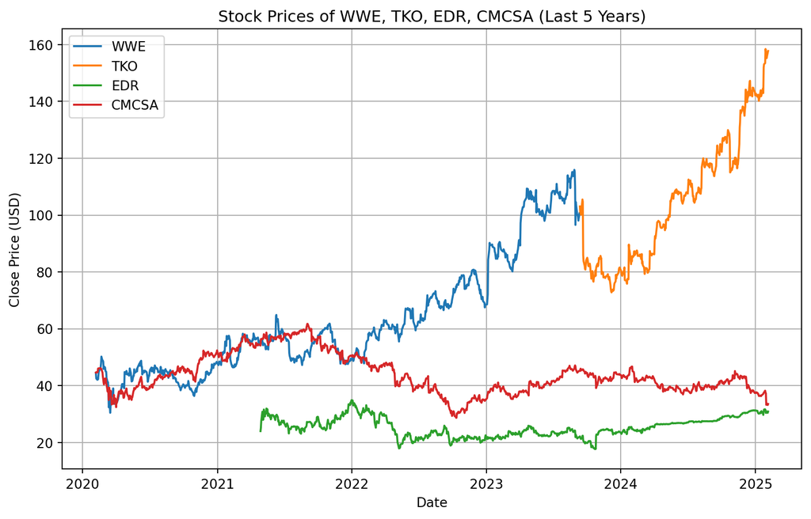

```python
import requests
import pandas as pd
import json
import matplotlib.pyplot as plt
import time  # For API request delay

API_KEY = "5qT0zvI29CudqPkIUclbkXERE3B4IdLeXufXEAzM"

# stock symbols to fetch
STOCK_SYMBOLS = ["WWE", "TKO", "EDR", "CMCSA"]

# DataFrame to store combined stock data
stock_prices = pd.DataFrame()

# Function to fetch stock data from Alpha Vantage
def fetch_stock_data(symbol, api_key):
    url = f'https://www.alphavantage.co/query?function=TIME_SERIES_DAILY&symbol={symbol}&outputsize=full&apikey={api_key}'
    response = requests.get(url)

    if response.status_code == 200:
        print(f"Successfully fetched data for {symbol}")
        return response.json()  # Return JSON response
    else:
        print(f"Failed to fetch data for {symbol} (status code: {response.status_code})")
        return None

# Function to process stock data and store it in a DataFrame
def process_stock_data(symbol, raw_data):
    if raw_data and "Time Series (Daily)" in raw_data:
        print(f"Processing data for {symbol}...")

        # Convert daily stock data to DataFrame
        df = pd.DataFrame.from_dict(raw_data["Time Series (Daily)"], orient='index', dtype='float')
        df.index = pd.to_datetime(df.index)  # Convert index to datetime
        df.sort_index(inplace=True)  # Sort by date

        # Keep only the 'close' price
        df = df[['4. close']].rename(columns={'4. close': f'{symbol} Close'})

        # Filter for the last 5 years
        df = df[df.index >= pd.Timestamp.now() - pd.DateOffset(years=5)]

        return df
    else:
        print(f"Data missing or invalid for {symbol}.")
        return None

# Loop through each stock symbol and fetch/process data
for symbol in STOCK_SYMBOLS:
    print(f"\nFetching data for {symbol}...")
    raw_data = fetch_stock_data(symbol, API_KEY)

    # Debugging: Print first few JSON keys (optional)
    if raw_data:
        print(json.dumps(list(raw_data.keys())[:5], indent=4))  # Print first 5 keys

    # Process data and merge it into the main DataFrame
    stock_df = process_stock_data(symbol, raw_data)
    if stock_df is not None:
        stock_prices = stock_df if stock_prices.empty else stock_prices.join(stock_df, how='outer')

    time.sleep(12)  # Wait 12 seconds to avoid API rate limits

# Plot the stock prices
plt.figure(figsize=(10, 6))
for symbol in STOCK_SYMBOLS:
    col_name = f'{symbol} Close'
    if col_name in stock_prices:
        plt.plot(stock_prices.index, stock_prices[col_name], label=symbol)

# Plot the graph
plt.title("Stock Prices of WWE, TKO, EDR, CMCSA (Last 5 Years)")
plt.xlabel("Date")
plt.ylabel("Close Price (USD)")
plt.legend()
plt.grid(True)
plt.show()
```

## Step 3

Just like every other nerdy hobby, professional wrestling draws dedicated fans. Wrestling fans often go to cagematch.net to leave reviews for matches, shows, and wrestlers. The following link contains the top 100 matches on cagematch: https://www.cagematch.net/?id=111&view=statistics

- What is the correlation between WON ratings and cagematch ratings?

```python
from bs4 import BeautifulSoup
import requests
import pandas as pd
import re

# Fetch the webpage
link = 'https://www.cagematch.net/?id=111&view=statistics'
top100_req = requests.get(link)
top100_soup = BeautifulSoup(top100_req.content, 'html.parser')

# Extract WON Ratings
top100_WON = top100_soup.select(".TCol.TColSeparator span.starRating")
won_list = [i.text.strip() for i in top100_WON]

# Convert WON Ratings to numeric values
def convert(i):
    stars = i.count('*')  # Count stars
    # Extract fraction if available
    fraction_match = re.search(r'(\d+)/(\d+)', i)
    if fraction_match:
        numerator, denominator = map(int, fraction_match.groups())
        fraction_value = numerator / denominator
    else:
        fraction_value = 0  # No fraction present
    return stars + fraction_value

# Convert WON ratings using the function
numeric_won = [convert(i) for i in won_list]

# Extract Cagematch Ratings
top100_rate = top100_soup.select(".TCol.TColSeparator  span.Rating.Color9")
rating_list = [float(i.text.strip()) for i in top100_rate]

# Create a DataFrame
df_matches = pd.DataFrame({
    'WON Rating': numeric_won,
    'Cagematch Rating': rating_list
})

# Calculate correlation
correlation = df_matches.corr().loc['WON Rating', 'Cagematch Rating']

# Print results
print(f"Correlation between WON Ratings and Cagematch Ratings: {correlation:.4f}")

# Display the first few rows to verify data
print(df_matches.head())
```

```
Correlation between WON Ratings and Cagematch Ratings: 0.2093
   WON Rating  Cagematch Rating
0        6.00              9.81
1        5.00              9.80
2        5.00              9.78
3        7.00              9.76
4        6.25              9.76
```

** Which wrestler has the most matches in the top 100?

```python
from bs4 import BeautifulSoup
import requests
import pandas as pd

# Step 1: Fetch the webpage
link = 'https://www.cagematch.net/?id=111&view=statistics'
response = requests.get(link)
soup = BeautifulSoup(response.content, 'html.parser')

# Step 2: Extract the match fixture data (contains wrestler names)
matches = soup.select(".TCol a")  # Selecting the match fixtures (wrestler names)
wrestler_list = []

# Step 3: Clean and split wrestler names
for match in matches:
    names = match.text.strip().split(" vs. ")  # Splitting wrestlers
    wrestler_list.extend(names)  # Add all wrestlers to the list

# Step 4: Count occurrences using Pandas
df_wrestlers = pd.DataFrame(wrestler_list, columns=["Wrestler"])
top_wrestlers = df_wrestlers["Wrestler"].value_counts()

print(top_wrestlers.head(10))
```

```
Wrestler
                     100
Kenny Omega           15
Kazuchika Okada       14
Bryan Danielson       11
Kenta Kobashi          9
Hiroshi Tanahashi      9
Will Ospreay           8
Mitsuharu Misawa       6
Kota Ibushi            6
Tetsuya Naito          5
Name: count, dtype: int64
```

*** Which promotion has the most matches in the top 100?

```python
from bs4 import BeautifulSoup
import requests
import pandas as pd

# Step 1: Fetch the webpage
url = "https://www.cagematch.net/?id=111&view=statistics"
response = requests.get(url)
soup = BeautifulSoup(response.content, "html.parser")

# Step 2: Locate the table containing match data
table = soup.find("table", class_="TBase TableBorderColor")
rows = table.find_all("tr")[1:]  # Skip header row

# Step 3: Extract promotions
promotions = []
for row in rows:
    columns = row.find_all("td")  # Get all columns
    if len(columns) > 2:  # Ensure there is a promotion column
        promo_td = columns[2]  # The Promotion column
        promo_img = promo_td.find("img")  # Locate the image tag inside the column

        if promo_img and promo_img.has_attr("alt"):
            promotions.append(promo_img["alt"])  # Extract promotion name from 'alt' attribute
        else:
            promotions.append("Unknown")  # Fallback if no promotion found

# Step 4: Convert to DataFrame and count occurrences
df_promotions = pd.DataFrame({"Promotion": promotions})
promotion_counts = df_promotions["Promotion"].value_counts()

# Step 5: Find the promotion with the most matches
top_promotion = promotion_counts.idxmax()
top_count = promotion_counts.max()

# Step 6: Print results
print(f"\nThe promotion with the most matches in the top 100 is: **{top_promotion}** with {top_count} matches.\n")
print("Full list of promotions and their match counts:")
print(promotion_counts)
```

```
The promotion with the most matches in the top 100 is: **New Japan Pro Wrestling** with 35 matches.

Full list of promotions and their match counts:
Promotion
New Japan Pro Wrestling                 35
World Wrestling Entertainment           14
All Japan Pro Wrestling                 12
All Elite Wrestling                     12
Ring Of Honor                            8
Pro Wrestling NOAH                       6
All Japan Women's Pro-Wrestling          4
World Wonder Ring Stardom                2
Total Nonstop Action Wrestling           1
GAEA Japan                               1
DDT Pro Wrestling                        1
Lucha Underground                        1
Japanese Women Pro-Wrestling Project     1
World Championship Wrestling             1
JTO                                      1
Name: count, dtype: int64
```

**** What is each promotion’s average WON rating?

```python
import pandas as pd

# Assuming df_matches contains WON Rating and df_promotions contains Promotion column
# Ensure both DataFrames have the same index before merging
df_combined = df_matches.copy()
df_combined["Promotion"] = df_promotions["Promotion"]  # Add the Promotion column

# Verify the merge
print("Merged DataFrame Preview:")
print(df_combined.head())

# Ensure WON Rating is numeric
df_combined["WON Rating"] = pd.to_numeric(df_combined["WON Rating"], errors="coerce")

# Group by Promotion and calculate the average WON Rating
avg_won_by_promotion = df_combined.groupby("Promotion")["WON Rating"].mean().sort_values(ascending=False)

# Display the results
print("\nAverage WON Rating for Each Promotion:")
print(avg_won_by_promotion)
```

```
Merged DataFrame Preview:
   WON Rating  Cagematch Rating                Promotion
0        6.00              9.81  New Japan Pro Wrestling
1        5.00              9.80       Pro Wrestling NOAH
2        5.00              9.78  New Japan Pro Wrestling
3        7.00              9.76  New Japan Pro Wrestling
4        6.25              9.76  New Japan Pro Wrestling

Average WON Rating for Each Promotion:
Promotion
All Elite Wrestling                     5.562500
New Japan Pro Wrestling                 5.392857
Japanese Women Pro-Wrestling Project    5.000000
Total Nonstop Action Wrestling          5.000000
World Championship Wrestling            5.000000
All Japan Pro Wrestling                 4.979167
World Wrestling Entertainment           4.892857
Pro Wrestling NOAH                      4.791667
JTO                                     4.750000
Ring Of Honor                           4.312500
All Japan Women's Pro-Wrestling         3.687500
World Wonder Ring Stardom               2.750000
DDT Pro Wrestling                       0.000000
GAEA Japan                              0.000000
Lucha Underground                       0.000000
Name: WON Rating, dtype: float64
```

***** Select any single match and get the comments and ratings for that match into a data frame.

```python
import requests
from bs4 import BeautifulSoup
import pandas as pd
import re

# URL of the match page with comments
URL = "https://www.cagematch.net/?id=111&nr=8034&page=99"

# Fetch and parse the webpage
response = requests.get(URL)
if response.status_code != 200:
    print(f"Failed to retrieve page (Status Code: {response.status_code})")
    exit()

soup = BeautifulSoup(response.content, "html.parser")

# Extract comments
comments_data = []
for comment in soup.find_all("div", class_="Comment"):
    author = comment.find("div", class_="CommentHeader").find("a")
    author = author.text.strip() if author else "Unknown"

    content_section = comment.find("div", class_="CommentContents")
    content = content_section.text.strip() if content_section else "No comment"

    # Extract rating if present
    rating_match = re.match(r"^\[(\d+\.\d+)\]\s*(.*)", content)
    rating = rating_match.group(1) if rating_match else "N/A"
    content = rating_match.group(2) if rating_match else content

    comments_data.append([author, rating, content])

# Convert to DataFrame and display
df_comments = pd.DataFrame(comments_data, columns=["Author", "Rating", "Comment"])
print(df_comments)
```

```
              Author Rating                                            Comment
0         Kugenesan1    9.0  "Agreed with the 6 stars rating but no matter ...
1         Josh Cagle    N/A  "This is a 10 for me all day. This was the mat...
2              wj198   10.0  "[******1/2] It's safe to say that this match ...
3     Jona5Holt on X   10.0  "This was the greatest match of all time. I wa...
4            joethom   10.0  "The match that broke a lot of brains, it is t...
..               ...    ...                                                ...
319  Rattlesnake3-16   10.0  "Oh my f***** god this math was simply the mos...
320      Hunter Dunn   10.0  "Okada/Tanahashi last year was said to be one ...
321   umarthegreat15   10.0  "It's no secret everyone had very high expecta...
322      RainmakerF7   10.0  "Expectations for this match were ridiculously...
323          Viper99   10.0  "Allein die aufmachung zu diesem Match war so ...

[324 rows x 3 columns]
```

## Step 4

You can’t have matches without wrestlers. The following link contains the top 100 wrestlers, according to cagematch: https://www.cagematch.net/?id=2&view=statistics

*** Of the top 100, who has wrestled the most matches? ***** Of the top 100, which wrestler has the best win/loss?

```python
import requests
from bs4 import BeautifulSoup
import re
import pandas as pd
import time

# Define headers to avoid being blocked
HEADERS = {
    "User-Agent": "Mozilla/5.0 (Windows NT 10.0; Win64; x64) AppleWebKit/537.36 (KHTML, like Gecko) Chrome/114.0.0.0 Safari/537.36"
}

# Base URL
BASE_URL = "https://www.cagematch.net"
WRESTLER_LIST_URL = f"{BASE_URL}/?id=2&view=statistics"

# Function to fetch the top 100 wrestlers' profile links
def get_wrestler_links():
    response = requests.get(WRESTLER_LIST_URL, headers=HEADERS)
    # Check if the request was successful
    if response.status_code != 200:
        print("Failed to fetch wrestler list.")
        return []
    # Parse the page content using BeautifulSoup
    soup = BeautifulSoup(response.text, 'html.parser')
    # Find the table containing the wrestler list
    table = soup.find("table", class_="TBase")
    if not table:
        print("Could not find the table of wrestlers.")
        return []

    wrestler_links = []
     # Loop through each row in the table
    for row in table.find_all("tr")[1:]:  # Skip header row
        # Find the first column in the row that contains the wrestler's profile link
        link_tag = row.find_all("td")[1].find("a")
        # Ensure the link is valid and contains the necessary identifier
        if link_tag and "nr=" in link_tag["href"]:
            wrestler_name = link_tag.text.strip()
            wrestler_id = re.search(r"nr=(\d+)", link_tag["href"]).group(1)
            # Construct the match statistics URL using the wrestler's ID
            match_stats_url = f"{BASE_URL}/?id=2&nr={wrestler_id}&page=22"
            wrestler_links.append((wrestler_name, match_stats_url))

    return wrestler_links

# Function to fetch match statistics for a given wrestler
def get_match_statistics(match_stats_url):
    # Send a GET request to fetch the wrestler's match statistics page
    response = requests.get(match_stats_url, headers=HEADERS)
    if response.status_code != 200:
        return None, None, None

    stats_text = BeautifulSoup(response.text, 'html.parser').get_text("\n")
    # Define a lambda function to extract numerical stats using regex
    extract_stat = lambda label: re.search(fr"{label}:\s*([\d,]+)", stats_text)

    # Extract match statistics
    match_count = extract_stat("Total number of matches")
    win_count = extract_stat("Total number of wins")
    loss_count = extract_stat("Total number of losses")

    # Convert extracted values to integers, removing commas for formatting
    return (
        int(match_count.group(1).replace(",", "")) if match_count else None,
        int(win_count.group(1).replace(",", "")) if win_count else None,
        int(loss_count.group(1).replace(",", "")) if loss_count else None
    )

# Main function to fetch stats for all wrestlers
def fetch_wrestler_stats():
    wrestler_links = get_wrestler_links() # Fetch top 100 wrestlers' profile links
    wrestler_stats = []

    for name, url in wrestler_links:
        print(f"Fetching stats for {name}...")
        matches, wins, losses = get_match_statistics(url)

        # Ensure all values are retrieved and valid
        if matches and wins and losses:
            wrestler_stats.append({
                'Wrestler': name,
                'Total Matches': matches,
                'Wins': wins,
                'Losses': losses,
                'Win/Loss Ratio': round(wins / losses, 2) if losses else None
            })

        time.sleep(2)  # Avoid being blocked

    return pd.DataFrame(wrestler_stats)

# Display results
df_wrestlers = fetch_wrestler_stats()
print(df_wrestlers.head())

# Identify the wrestler with the most matches
if not df_wrestlers.empty:
    top_wrestler = df_wrestlers.loc[df_wrestlers["Total Matches"].idxmax()]
    print(f"Most Matches: {top_wrestler['Wrestler']} ({top_wrestler['Total Matches']} matches)")

    best_wrestler = df_wrestlers.loc[df_wrestlers["Win/Loss Ratio"].idxmax()]
    print(f"Best Win/Loss Ratio: {best_wrestler['Wrestler']} ({best_wrestler['Win/Loss Ratio']})")
```

```
Fetching stats for Kenta Kobashi...
Fetching stats for Mitsuharu Misawa...
Fetching stats for Toshiaki Kawada...
Fetching stats for Mayu Iwatani...
Fetching stats for Manami Toyota...
Fetching stats for Akira Hokuto...
Fetching stats for Jumbo Tsuruta...
Fetching stats for Kazuchika Okada...
Fetching stats for Hiroshi Tanahashi...
Fetching stats for Bryan Danielson...
Fetching stats for Gunther...
Fetching stats for Jushin Thunder Liger...
Fetching stats for Shawn Michaels...
Fetching stats for Kenny Omega...
Fetching stats for Lou Thesz...
Fetching stats for Kurt Angle...
Fetching stats for Meiko Satomura...
Fetching stats for Paul Heyman...
Fetching stats for Eddie Guerrero...
Fetching stats for Steve Austin...
Fetching stats for AJ Styles...
Fetching stats for IYO SKY...
Fetching stats for Hiroyuki Unno...
Fetching stats for Bobby Heenan...
Fetching stats for Aja Kong...
Fetching stats for Gene Okerlund...
Fetching stats for Tiger Mask...
Fetching stats for Bret Hart...
Fetching stats for Tetsuya Naito...
Fetching stats for Karl Gotch...
Fetching stats for Syuri...
Fetching stats for Minoru Suzuki...
Fetching stats for Katsuyori Shibata...
Fetching stats for Arisa Nakajima...
Fetching stats for Howard Finkel...
Fetching stats for Undertaker...
Fetching stats for Kento Miyahara...
Fetching stats for Tomohiro Ishii...
Fetching stats for Asuka...
Fetching stats for Terry Funk...
```

[output cut: 53 more lines]

```
Fetching stats for Hechicero...
Fetching stats for Akira Taue...
Fetching stats for Ric Flair...
Fetching stats for Great Sasuke...
Fetching stats for Suzu Suzuki...
Fetching stats for Chris Hero...
Fetching stats for Sareee...
           Wrestler  Total Matches  Wins  Losses  Win/Loss Ratio
0     Kenta Kobashi           2405  1195    1152            1.04
1  Mitsuharu Misawa           3557  1937    1441            1.34
2   Toshiaki Kawada           3043  1477    1398            1.06
3      Mayu Iwatani           1022   494     460            1.07
4     Manami Toyota           2740  1616    1009            1.60
Most Matches: Ric Flair (4999 matches)
Best Win/Loss Ratio: Lou Thesz (9.45)
```

## Step 5

With all of this work out of the way, we can start getting down to strategy.

First, what talent should WWE pursue? Advise carefully.

WWE should pursue established wrestlers like Kazuchika Okada from New Japan Pro Wrestling, who has consistently appeared in top-rated matches based on Cagematch and WON ratings. Our data shows that New Japan Pro Wrestling leads in high-rated matches, with Okada frequently involved in some of the most critically acclaimed bouts. His proven drawing power, in-ring storytelling, and global appeal make him an ideal target for WWE to attract a wider audience and enhance match quality.

Second, reconcile what you found in steps 3 and 4 with Netflix’s relationship with WWE. Use the data from the following page to help make your case: https://wrestlenomics.com/tv-ratings/

Third, do you have any further recommendations for WWE?

WWE’s move to Netflix offers global exposure. To maximize impact, WWE should create exclusive Netflix specials, documentaries, or behind-the-scenes content, leveraging the platform’s storytelling strengths to engage both casual and hardcore wrestling fans.